# Harvest

Carol Hardy

2022-07-19

## Flour Types

#### First, I scraped all the data from the website “https://www.nutritionadvance.com/types-of-flour/.”

In reality, all of this data was available to download in .csv form. However, I want to hone in a new skill.

```r
url <- 'https://www.nutritionadvance.com/types-of-flour/'
webpage <- read_html(url)

#Using CSS selectors to scrape
flour_html <- webpage %>%
  html_elements('h2')

#Converting the data to text
flour <- as.data.frame(html_text2(flour_html))
head(flour)
```

```
##   html_text2(flour_html)
## 1         1) Acorn Flour
## 2        2) Almond Flour
## 3      3) Amaranth Flour
## 4     4) Arrowroot Flour
## 5        5) Barley Flour
## 6         6) Bread Flour
```

```r
#Using CSS selectors to scrape
nutri_html <- webpage %>%
  html_elements('li+ li')

#Converting the data to text
nutri <- as.data.frame(html_text2(nutri_html))
head(nutri)
```

```
##   html_text2(nutri_html)
## 1                Contact
## 2         Privacy Policy
## 3                 Drinks
## 4                  Foods
## 5              Nutrition
## 6
```

```r
#Using CSS selectors to scrape
type_html <- webpage %>%
  html_elements('li:nth-child(1)')

#Converting the data to text
type <- as.data.frame(html_text2(type_html))
head(type)
```

```
##        html_text2(type_html)
## 1                      About
## 2                      Diets
## 3         Type of flour: nut
## 4         Type of flour: nut
## 5 Type of flour: whole grain
## 6  Type of flour: root/tuber
```

#### Data Cleaning

Now comes the difficult part. I am going to clean all the data to make it usable.

```r
names(nutri)[names(nutri) == 'html_text2(nutri_html)'] <- 'nut' # rename variable
nutri <- nutri %>% slice(- c(1:6, 44:49)) # remove the rows that are not needed
nutri$nut <- str_remove(nutri$nut[str_detect(nutri$nut, 'Basic nutritional values per 100g:')], 'Basic nutritional values per 100g:') # remove the unnecessary text
nutri <- separate(nutri, nut, into = c("calorie", "carbs", "fiber", "fat", "protein"), sep = ",") %>%# split variable, there are some missing values now
  slice(- c(1, 20,29)) #removed rows because I do not want missing data

nutri$calorie <- as.numeric(str_remove(nutri$calorie[str_detect(nutri$calorie, 'calories')], 'calories')) # remove the unnecessary text
nutri$carbs <- as.numeric(str_remove(nutri$carbs[str_detect(nutri$carbs, 'g carbohydrate')], 'g carbohydrate')) # remove the unnecessary text
nutri$fiber <- as.numeric(str_remove(nutri$fiber[str_detect(nutri$fiber, 'g fiber')], 'g fiber')) # remove the unnecessary text
nutri$protein <- str_remove(nutri$protein[str_detect(nutri$protein, 'g protein')], 'g protein') # remove the unnecessary text
nutri$fat <- as.numeric(str_remove(nutri$fat[str_detect(nutri$fat, 'g fat')], 'g fat')) # remove the unnecessary text

nutri <- nutri %>% separate(protein, into = c(NA,"protein"), "\\s") # split variable to get only protein
nutri <- nutri %>% mutate(protein = as.numeric(protein))
head(nutri)
```

```
##   calorie carbs fiber  fat protein
## 1     590  18.7   9.9 52.5    21.4
## 2     400  71.4  11.4  5.7    14.3
## 3     357  88.2   3.4  0.1     0.3
## 4     345  74.5  10.1  1.6    10.5
## 5     361  72.5   2.4  1.7    12.0
## 6     363  76.5   4.6  2.8     7.2
```

```r
names(flour)[names(flour) == 'html_text2(flour_html)'] <- 'flour_name' # rename variable
flour <- flour %>% slice(-(38:41)) # remove the rows that are not flour types
flour <- separate(flour, flour_name, into = c("number", "flour_name"), sep = "^\\S*\\K\\s+") # split variable
flour <- subset(flour, select = -number ) %>%# remove unnecessary column
  slice(- c(1, 20,29)) %>% #removed rows because I do not want missing data
  mutate(flour_name = as.factor(flour_name))
head(flour)
```

```
##         flour_name
## 1     Almond Flour
## 2   Amaranth Flour
## 3  Arrowroot Flour
## 4     Barley Flour
## 5      Bread Flour
## 6 Brown Rice Flour
```

```r
names(type)[names(type) == 'html_text2(type_html)'] <- 'type' # rename variable
type <- type %>% slice(-c(1:2, 40:41))
type$type <- str_remove(type$type[str_detect(type$type, 'Type of flour:')], 'Type of flour:') # remove the unnecessary text
type <- type %>% mutate(type = as.factor(type)) %>%
  slice(- c(1, 20,29))
```

```r
#put it all together
flour <- bind_cols(flour, type, nutri)
head(flour)
```

```
##         flour_name           type calorie carbs fiber  fat protein
## 1     Almond Flour            nut     590  18.7   9.9 52.5    21.4
## 2   Amaranth Flour    whole grain     400  71.4  11.4  5.7    14.3
## 3  Arrowroot Flour     root/tuber     357  88.2   3.4  0.1     0.3
## 4     Barley Flour    whole grain     345  74.5  10.1  1.6    10.5
## 5      Bread Flour  refined grain     361  72.5   2.4  1.7    12.0
## 6 Brown Rice Flour    whole grain     363  76.5   4.6  2.8     7.2
```

#### Data Exploration

```r
table(flour$type)
```

```
##
##         insect         legume            nut  refined grain     root/tuber
##              1              4              4              6              4
##           seed    whole grain
##              1             14
```

```r
levels(flour$type)
```

```
## [1] " insect"        " legume"        " nut"           " refined grain"
## [5] " root/tuber"    " seed"          " whole grain"
```

Here we can see that the data is quite unbalanced. There is only one type of flour that is made of insects (cricket flour). I will probably need to remove this in order to perform the training and testing for the random forest. I also will combine the seed type flour (sunflower) with the nut type flower. I think those categories are similar enough that it makes sense.

```r
levels(flour$type) <- c("insect", "legume", "nut", "refined grain", "root/tuber", "nut", "whole grain") # change the names to combine seed w/ nut and remove the whitespace in front of the level name
levels(flour$type)
```

```
## [1] "insect"        "legume"        "nut"           "refined grain"
## [5] "root/tuber"    "whole grain"
```

```r
table(flour$type)
```

```
##
##        insect        legume           nut refined grain    root/tuber
##             1             4             5             6             4
##   whole grain
##            14
```

#### Data Viz

In Appendix B of ROS (Regression and Other Stories) the authors encourage making many graphs, but they do not want to see the irrelevant graphs. So I am going to try to do that. They also encourage graphing the fitted model.

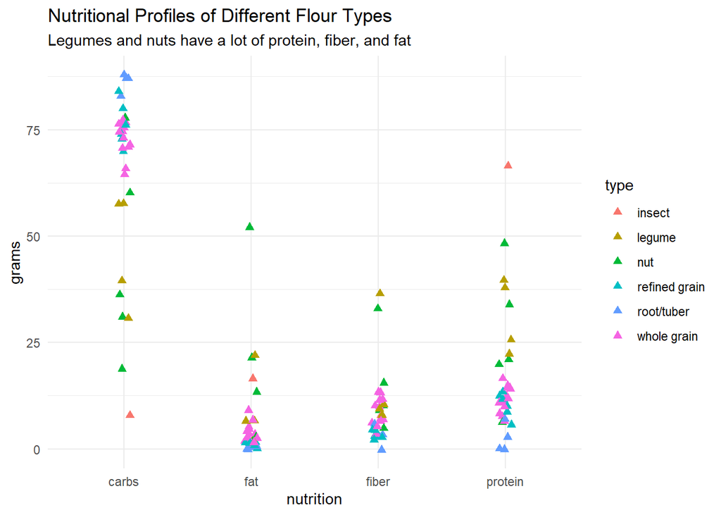

There seems to be some distinctive binning between the different flour types. So I think the random forest algorithm will be able to parse the various flour types. For example, the root/tuber flours are high in carbs, but very low in protein.

```r
#put data into long format
flour_long <- flour %>%
  select("type", "carbs", "fiber", "fat","protein") %>%
  pivot_longer(-type, names_to = "nutrition", values_to ="grams")

flour_long %>% ggplot(aes(x = nutrition, y = grams, color = type)) + # make plot
  geom_jitter(size = 2, shape = 17, width = .05, height = .5) +
  theme_minimal() +
  ggtitle("Nutritional Profiles of Different Flour Types", subtitle = "Legumes and nuts have a lot of protein, fiber, and fat")
```

### Random Forest

There is not enough data for how many type of flour there are so I am going to combine types into four categories. There will be a legume/nut/insect category.

```r
levels(flour$type) <- c("legume/nut/insect", "legume/nut/insect", "legume/nut/insect", "refined grain", "root/tuber", "whole grain") # change the names to combine
levels(flour$type)
```

```
## [1] "legume/nut/insect" "refined grain"     "root/tuber"
## [4] "whole grain"
```

```r
table(flour$type)
```

```
##
## legume/nut/insect     refined grain        root/tuber       whole grain
##                10                 6                 4                14
```

Before going to the random forest, I want to visualize a single decision tree using the entire dataset.

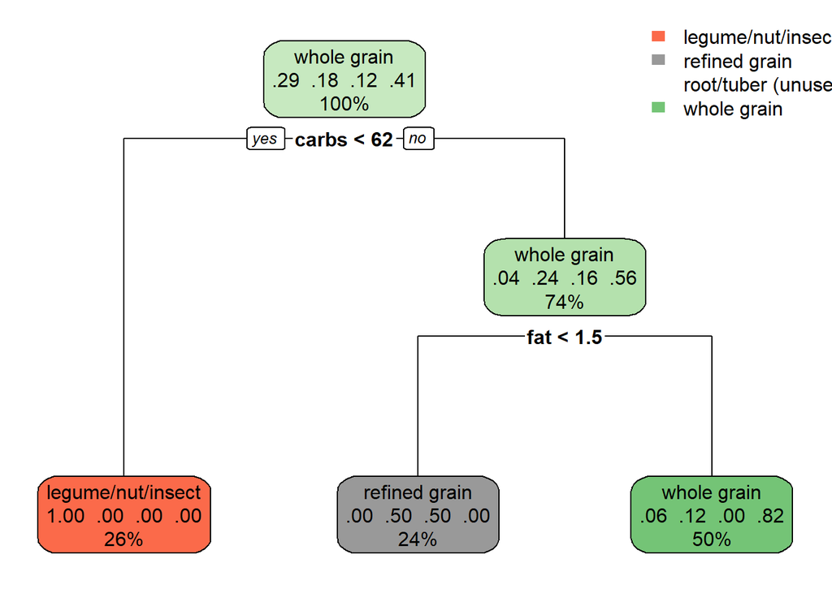

```r
tree <- rpart(type ~ calorie + carbs + fiber + fat + protein , data = flour, method = 'class')
rpart.plot(tree)
```

**How to read a single tree:**

- The top line of each node shows the type of flour being predicted. So in the first node it makes sense that the algorithm would predict whole grain wheat because that is the type of flour that occurs most often in the data set.
- The second line in each node is the predicted probability of each type (order: legume/nut/insect, refined grain, root/tuber, whole grain). So the final node labeled ‘refined grain’ has a 50% chance of being in the root/tuber category.
- The bottom line of each node shows the percentage of observations in the node. For example 50% of the flours are predicted to be whole grain in the final nodes (bottom line).
- We can see that root/tuber flour types are never predicted because the category is marked as unused in the legend.

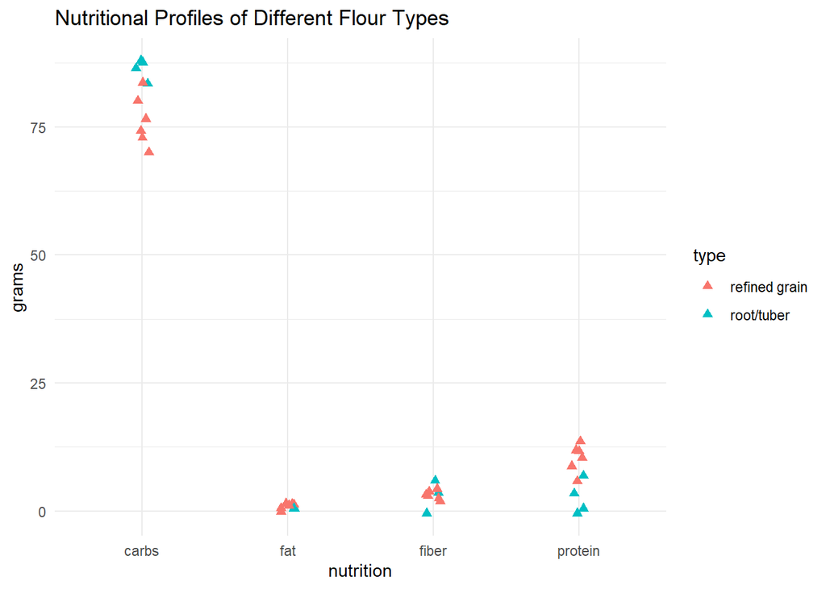

The algorithm is not able to tell the difference between refined grain and root/tuber flour based off the predictors in the data (Maybe we would need to add taste to the data?). Here is a plot of only those two types of flour. The single tree was using fat and carbs to classify the type of flour. When looking at this plot, both types of flour look very similar in terms of carbs and fat.

```r
#put data into long format
flour_long <- flour %>%
  select("type", "carbs", "fiber", "fat", "protein") %>%
  pivot_longer(-type, names_to = "nutrition", values_to ="grams") %>%
  filter(type  %in% c("root/tuber", "refined grain"))

flour_long %>% ggplot(aes(x = nutrition, y = grams, color = type)) + # make plot
  geom_jitter(size = 2, shape = 17, width = .05, height = .5) +
  theme_minimal() +
  ggtitle("Nutritional Profiles of Different Flour Types")
```

In contrast to a single decision tree, the random forest is an ensemble of these trees. Random forests are non-linear meaning they will account for interactions. First we will split the data into training and testing data sets. In looking at Leo Breiman and Adele Cutler’s website on random forests (https://www.stat.berkeley.edu/~breiman/RandomForests/cc_home.htm#ooberr), the algorithm will internally use a leave on out method of analysis.

```r
set.seed(20221907)
f <- sample(2, nrow(flour), replace = TRUE, prob = c(0.8, 0.2))
train <- flour[f==1,]
test <- flour[f==2,]
```

The random forest below is fitting 200 different decision trees because this minimized the oob.

```r
rf <- randomForest(type ~ calorie + carbs + fiber + fat + protein , data = flour, ntree = 200, importance = T)
print(rf)
```

```
##
## Call:
##  randomForest(formula = type ~ calorie + carbs + fiber + fat +      protein, data = flour, ntree = 200, importance = T)
##                Type of random forest: classification
##                      Number of trees: 200
## No. of variables tried at each split: 2
##
##         OOB estimate of  error rate: 14.71%
## Confusion matrix:
##                   legume/nut/insect refined grain root/tuber whole grain
## legume/nut/insect                 9             0          0           1
## refined grain                     0             4          0           2
## root/tuber                        0             1          3           0
## whole grain                       0             1          0          13
##                   class.error
## legume/nut/insect  0.10000000
## refined grain      0.33333333
## root/tuber         0.25000000
## whole grain        0.07142857
```

A look at **variable importance:**

- The values on the x-axis are all of relative, not absolute, importance.
- The mean decrease accuracy is an estimate of how much model performance is lost when a predictor is removed.
- The mean decrease gini is a relative measure of how often a node was split based on a particular variable.

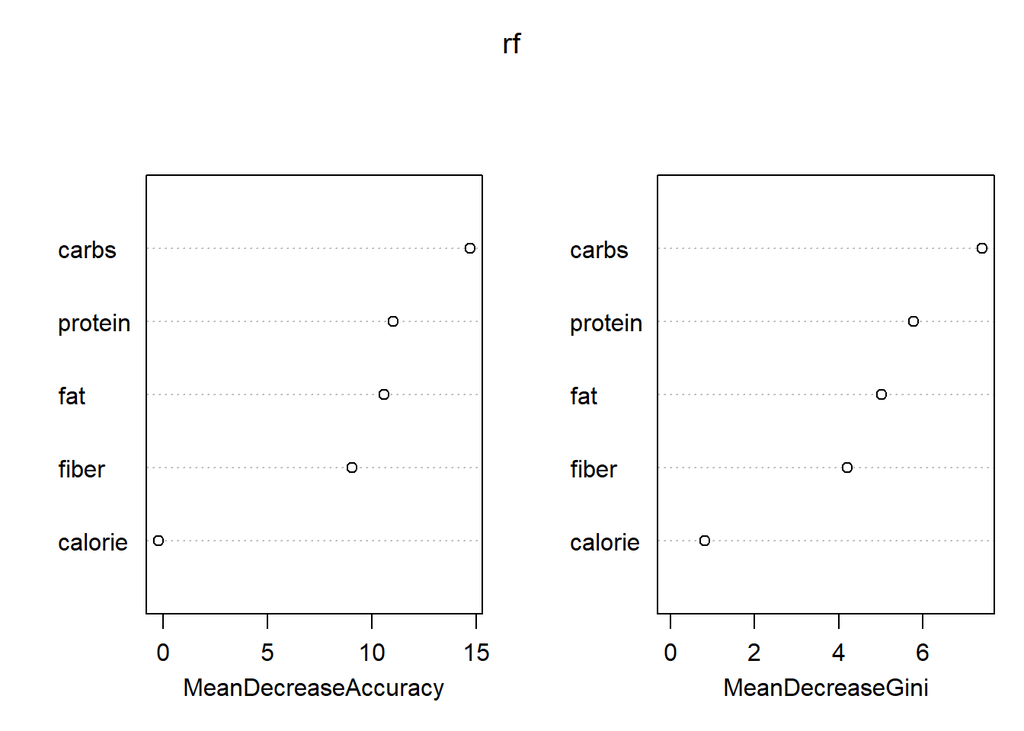

```r
varImpPlot(rf)
```

Note: I saved the .csv used for the analysis as: “write.csv(flour, ‘C:\Users\enilo\Dropbox\506\Personal_Proj\flour_data.csv’).” However, all the code used to make the dataset is in the file and (should be) reproducible.

Resources Used:

- https://www.stat.berkeley.edu/~breiman/RandomForests/cc_home.htm#giniimp
- https://www.blopig.com/blog/2017/04/a-very-basic-introduction-to-random-forests-using-r/
- https://www.nutritionadvance.com/types-of-flour/
- https://www.analyticsvidhya.com/blog/2017/03/beginners-guide-on-web-scraping-in-r-using-rvest-with-hands-on-knowledge/
- https://avehtari.github.io/ROS-Examples/examples.html